# Lab 1: Gapminder Data Visualization

## Github Repository Link:

[Link to Repository](https://github.com/DanielPelerman/GSB-544-Git/tree/main/Week%201/Lab%201)

## Task 1

The table below shows the first 5 rows of the dataset `q1`, which give us a preview of the variables we’ll be using for visualization in Figure 1.

```python
import pandas as pd
q1 = pd.read_csv("Lab 1 Data/q1data.csv")
q1.head()
```

|  | income | life_exp | population | year | country | four_regions | six_regions | eight_regions | world_bank_region |
| --- | --- | --- | --- | --- | --- | --- | --- | --- | --- |
| 0 | 1910.0 | 61.0 | 29200000.0 | 2010 | Afghanistan | asia | south_asia | asia_west | South Asia |
| 1 | 11100.0 | 78.1 | 2950000.0 | 2010 | Albania | europe | europe_central_asia | europe_east | Europe & Central Asia |
| 2 | 11100.0 | 74.7 | 36000000.0 | 2010 | Algeria | africa | middle_east_north_africa | africa_north | Middle East & North Africa |
| 3 | 46900.0 | 81.9 | 84500.0 | 2010 | Andorra | europe | europe_central_asia | europe_west | Europe & Central Asia |
| 4 | 7680.0 | 60.8 | 23400000.0 | 2010 | Angola | africa | sub_saharan_africa | africa_sub_saharan | Sub-Saharan Africa |

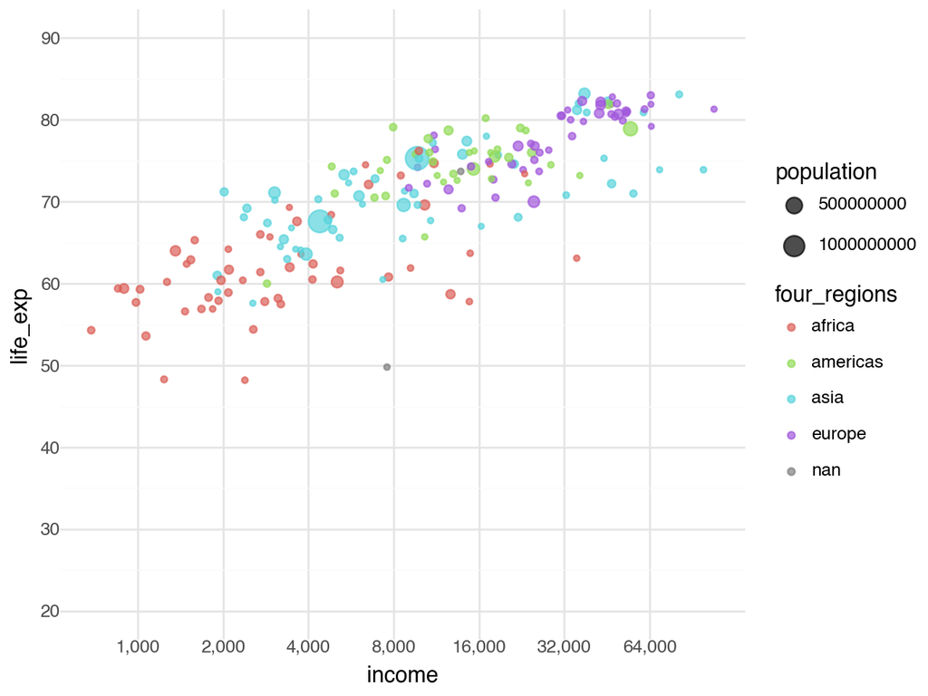

Figure 1: Relationship between income and life expectancy.

```python
from plotnine import ggplot, aes, geom_point, theme_minimal, labs, scale_x_continuous, scale_y_continuous
from mizani.formatters import comma_format
(ggplot(q1, aes(x = "income", y = "life_exp", size = "population", color = "four_regions"))
+ geom_point(alpha=0.7)
+ theme_minimal()
+ scale_x_continuous(
    trans = "log2",
    breaks = [500, 1000, 2000, 4000, 8000, 16000, 32000, 64000, 1280000],
    labels = comma_format())
+ scale_y_continuous(
    limits=[20,90],
    breaks=range(20, 91, 10)
)
)
```

The graph below demonstrates a plot for the `q1` dataset created using `geom_boxplot` instead of `geom_point`.

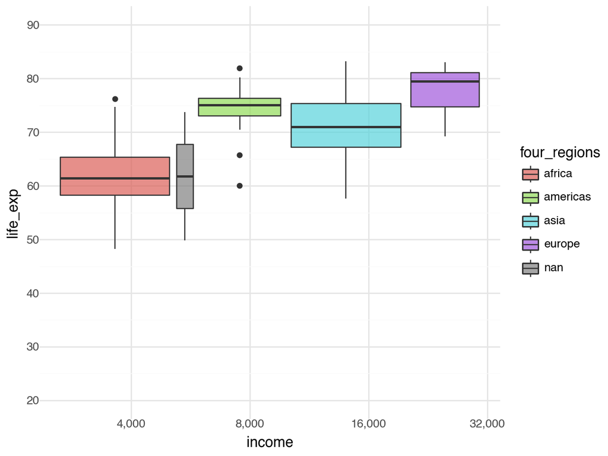

```python
from plotnine import geom_boxplot
(
    ggplot(q1, aes(x="income", y="life_exp", fill="four_regions"))
    + geom_boxplot(alpha=0.7)
    + theme_minimal()
    + scale_x_continuous(
    trans = "log2",
    breaks = [500, 1000, 2000, 4000, 8000, 16000, 32000, 64000, 1280000],
    labels = comma_format())
+ scale_y_continuous(
    limits=[20,90],
    breaks=range(20, 91, 10)
)
)
```

This graph isn’t the best choice for visualizing the data, but it still conveys the overall pattern. Like the scatterplot above, it shows that countries with lower incomes tend to have lower life expectancies, while higher incomes are associated with longer life spans. However, the boxplots obscure much of the variation within regions and fail to capture the full spread of incomes across individual countries.

## Task 2

The Table below shows the first 5 rows of the dataset `q2`, which gives us a preview of the variables we’ll be using for visualization in Figure 2.

```python
q2 = pd.read_csv("Lab 1 Data/q2data.csv")
q2.head()
```

|  | imports | exports | energy | year | country | four_regions | six_regions | eight_regions | world_bank_region |
| --- | --- | --- | --- | --- | --- | --- | --- | --- | --- |
| 0 | NaN | NaN | NaN | 1997 | Afghanistan | asia | south_asia | asia_west | South Asia |
| 1 | 36.7 | 11.5 | 427 | 1997 | Albania | europe | europe_central_asia | europe_east | Europe & Central Asia |
| 2 | 22.5 | 22.6 | 825 | 1997 | Algeria | africa | middle_east_north_africa | africa_north | Middle East & North Africa |
| 3 | NaN | NaN | NaN | 1997 | American Samoa | NaN | NaN | NaN | NaN |
| 4 | NaN | NaN | 434 | 1997 | Angola | africa | sub_saharan_africa | africa_sub_saharan | Sub-Saharan Africa |

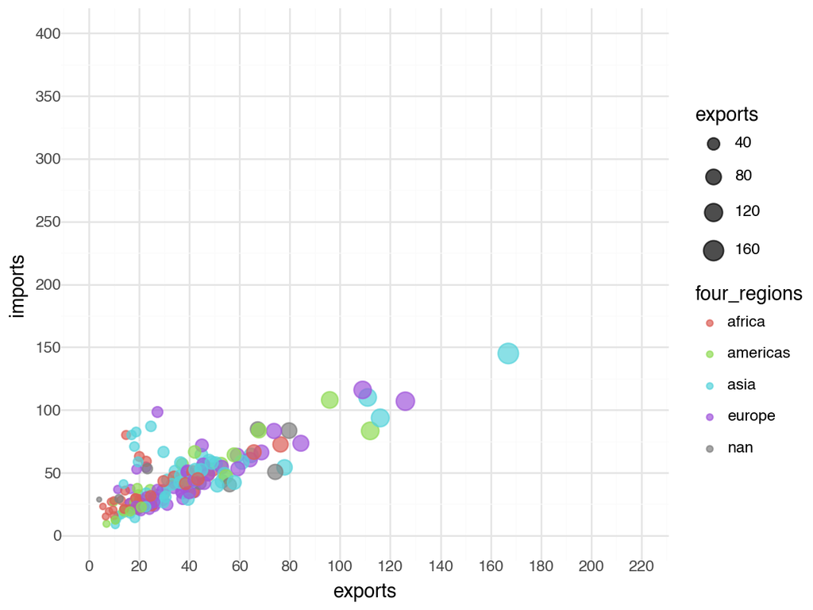

Figure 2: Relationship between imports and exports

```python
(
    ggplot(q2, aes(x = "exports", y = "imports", size = "exports", color = "four_regions"))
    + geom_point(alpha = 0.7)
    + theme_minimal()
    + scale_x_continuous(
        limits = [0, 220],
        breaks = range(0, 221, 20)
    )
    + scale_y_continuous(
        limits=[0, 400],
        breaks = range(0, 401, 50)
    )
)
```

The graph below demonstrates a plot for the `q2` dataset created using `geom_violin` instead of `geom_point`.

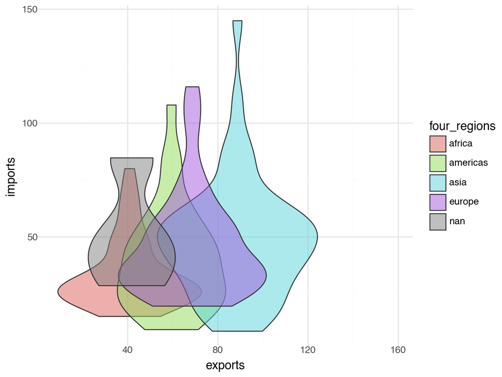

```python
from plotnine import geom_violin
(
    ggplot(q2, aes(x = "exports", y = "imports", fill = "four_regions"))
    + geom_violin(alpha = 0.5)
    + theme_minimal()
)
```

This plot is not well-suited for the data because violin plots are primarily designed to display the distribution of a single variable. While they provide some sense of variation within regions, they do not effectively capture the relationship between imports and exports, which was the original focus of the visualization

## Task 3

The Table below shows the first 5 rows of the dataset `q3`, which gives us a preview of the variables we’ll be using for visualization in Figure 3.

```python
q3 = pd.read_csv("Lab 1 Data/q3data.csv")
q3.head()
```

|  | internet_users | gdp | income | year | country | four_regions | six_regions | eight_regions | world_bank_region |
| --- | --- | --- | --- | --- | --- | --- | --- | --- | --- |
| 0 | 0.00456 | 330.0 | 1190.0 | 2001 | Afghanistan | asia | south_asia | asia_west | South Asia |
| 1 | 0.39000 | 2570.0 | 6780.0 | 2001 | Albania | europe | europe_central_asia | europe_east | Europe & Central Asia |
| 2 | 1.59000 | 3770.0 | 9230.0 | 2001 | Algeria | africa | middle_east_north_africa | africa_north | Middle East & North Africa |
| 3 | NaN | 10500.0 | NaN | 2001 | American Samoa | NaN | NaN | NaN | NaN |
| 4 | 11.30000 | 42600.0 | 35600.0 | 2001 | Andorra | europe | europe_central_asia | europe_west | Europe & Central Asia |

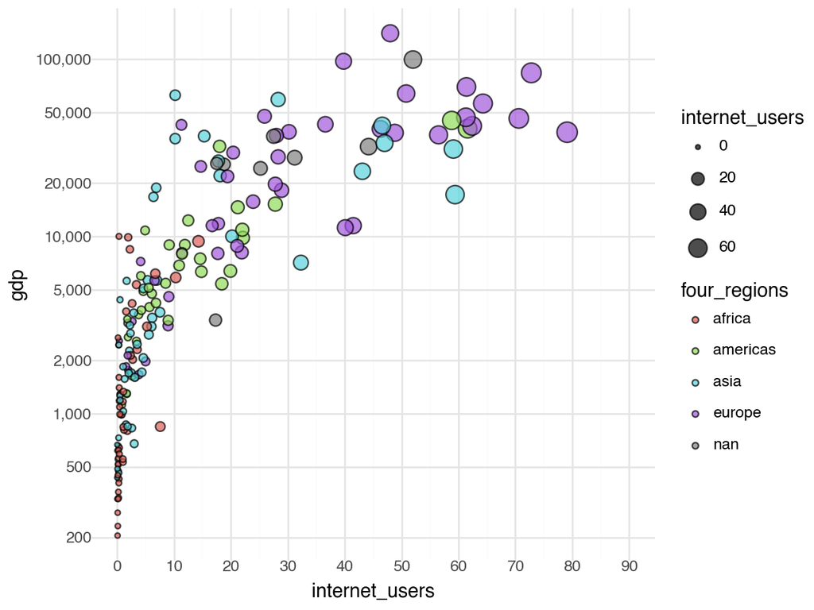

```python
(
    ggplot(q3, aes(x = "internet_users", y = "gdp", size = "internet_users", fill = "four_regions"))
    + geom_point(alpha = 0.7)
    + theme_minimal()
    + scale_x_continuous(
        limits = [0, 90],
        breaks = range(0, 91, 10)
    )
    + scale_y_continuous(
        trans = "log2",
        breaks = [200, 500, 1000, 2000, 5000, 10000, 20000, 50000, 100000],
        labels = comma_format()
    )
)
```

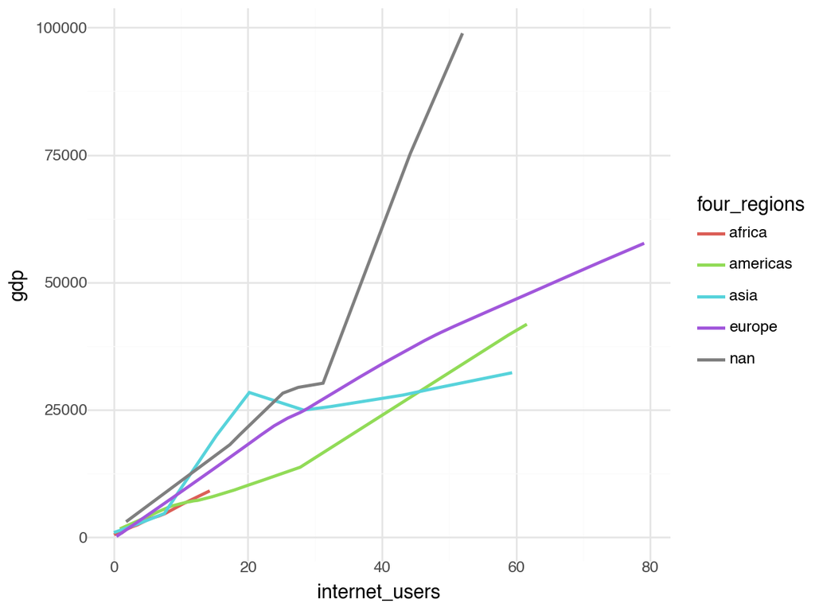

```python
from plotnine import geom_smooth
(
    ggplot(q3, aes(x = "internet_users", y = "gdp", color = "four_regions"))
+ geom_smooth(se=False)
+ theme_minimal()
)
```

The line graph made with `geom_smooth` is not a good fit for this dataset. Line graphs are better for showing changes over time, but here the data is cross-sectional and not in a natural order. Connecting the countries with lines suggests a trend that doesn’t really exist. While the graph shows some differences between regions, it hides the spread of individual data points. Overall, the scatterplot does a better job of showing the relationship between GDP and internet users.